# Визуализация данных с помощью ggplot2, часть 1

### Упражнение: определение эстетики

В этом упражнении продолжите работу с набором данных `diamonds`.

Постройте визуализацию зависимости цены бриллианта от его веса и класса огранки (`cut`), запустив следующий блок кода.

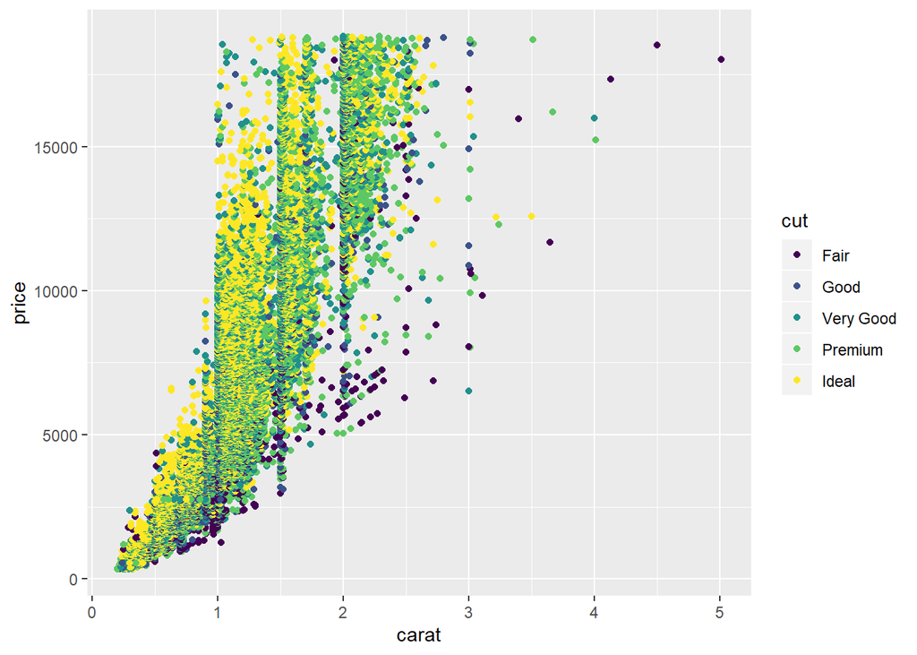

```r
# Измените код, чтобы задать прозрачность всех точек 5%
ggplot(data = diamonds) +
  geom_point(mapping =
               aes(x = carat, y = price,
                   colour = cut))
```

Точки на графике плохо различимы из-за наложения. Ваша задача - сделать точки полупрозрачными (прозрачность - 5%, или 0.05).

# Геомы и статистики

**Геомы** (**geom**) - это геометрические объекты, которые используются для визуализации данных на графике. Можно рассматривать их как разные способы визуализации данных. Например, на диаграмме рассеяния для визуализации используются точки (`geom_point()`), на ящичной диаграмме - ящики (`geom_boxplot()`), на гистограмме или столбиковой диаграмме - столбики (`geom_bar()`).

В `ggplot2` поддерживается большое количество типов визуализации, реализованных в виде функций `geom_...()`. Вы можете добавлять геомы к своей визуализации как отдельные слои.

Со списком доступных геомов можно познакомиться:

- в [документации ggplot2](http://ggplot2.tidyverse.org/reference/#section-layer-geoms)
- или в [шпаргалке по ggplot2](https://www.rstudio.com/wp-content/uploads/2016/11/ggplot2-cheatsheet-2.1.pdf).

Шпаргалка всегда доступна в меню RStudio: `Help>Cheatsheets>Data visualization with ggplot2`.

В этом блокноте мы рассмотрим несколько геомов, которые можно использовать для визуализации распределений количественных переменных.